# Limpieza Base FONDEN

Andrea García Tapia

23 de junio de 2015

# Introduction

La base de datos de Recursos Autorizados por Declaratoria de Desastre del [FONDEN](http://www.proteccioncivil.gob.mx/es/ProteccionCivil/Recursos_Autorizados_por_Declaratoria_de_Desastre) viene en PDF por año y la de apoyos para emergencias [SINAPROC[(http://www.proteccioncivil.gob.mx/es/ProteccionCivil/2013) viene por boletin y material usado. Para la elaboración de una base que abarcara los tres años de gasto público estatal y federal para atender las declaratorias de “Desastre”" generadas por las tormentas tropicales Ingrid y Manuel en septiembre del 2013 se elaboraron los siguietes pasos:

1. Conversión el PDF a un CVS
2. Extracción de las observaciónes durante el periodo 09/09/13 - 02/10/13
3. Homologación campos (cada año cambiaba el formato del documento y la información que traia)
4. Quitar acentos y similares
5. Deflactar: se trajeron los montos a precio constante (real de 2015), para ello se utilizó el promedio anual del Índice Nacional de Precios al Consumidor [INPC](http://www.inegi.org.mx/sistemas/indiceprecios/Estructura.aspx?idEstructura=112000200010&T=%C3%8Dndices%20de%20Precios%20al%20Consumidor&ST=Principales%20%C3%ADndices).

Las bases estan guardadas en la carpeta de Datos -> FONDEN -> “FONDEN_IM_año”

Las bases tienen 18 variables, la columna documento se refiere al documento de FONDEN del cual se obtuvieron los datos. Cabe mencionar que en 2014 se creó un Fondo extra llamado “FONDO GUERRERO”

```r
names(FIM_2013)
```

```
##  [1] "Documento"                      "Estado"
##  [3] "Evento"                         "Municipios"
##  [5] "Solicitud.de.Declaratoria"      "Fecha.publicacion.DOF"
##  [7] "Acuerdo.Comite.Tecnico"         "Sectores.Afectados"
##  [9] "Competencia"                    "Apoyos.Parciales.Inmdiatos"
## [11] "Gastos.de.Evaluacion"           "Anticipos"
## [13] "Acciones.de.Restauracion"       "Aportacion.FONDEN"
## [15] "Aportacion.Estatal"             "Aportacion.Dependencia.Federal"
## [17] "Recursos.Fondo.Guerrero"        "Aportacion.Total"
```

```r
str(FIM_2013)
```

```
## 'data.frame':    145 obs. of  18 variables:
##  $ Documento                     : int  2013 2013 2013 2013 2013 2013 2013 2013 2013 2013 ...
##  $ Estado                        : chr  "Chiapas" "Chiapas" "Chiapas" "Chiapas" ...
##  $ Evento                        : chr  "Movimiento de Ladera del 12 al 14 de septiembre de 2013" "Movimiento de Ladera del 12 al 14 de septiembre de 2014" "Lluvia severa los dias 12 al 15 de septiembre 2013" "Lluvia severa los dias 12 al 15 de septiembre 2013" ...
##  $ Municipios                    : int  1 1 3 3 3 3 3 1 1 1 ...
##  $ Solicitud.de.Declaratoria     : chr  "18/09/13" "18/09/13" "18/09/13" "18/09/13" ...
##  $ Fecha.publicacion.DOF         : chr  "27/09/13" "27/09/13" "27/09/13" "27/09/13" ...
##  $ Acuerdo.Comite.Tecnico        : chr  "SE.154.01 31-oct-13" "SE.154.01 31-oct-14" "SE.156.01 22-nov-13" "SE.157.01 02-Dic-13" ...
##  $ Sectores.Afectados            : chr  "Hidraulico" "Vivienda" "Carretero" "Carretero" ...
##  $ Competencia                   : chr  "Estatal" "" "Estatal" "Federal" ...
##  $ Apoyos.Parciales.Inmdiatos    : int  0 0 0 0 0 0 0 0 0 0 ...
##  $ Gastos.de.Evaluacion          : int  NA NA NA NA NA NA NA NA NA NA ...
##  $ Anticipos                     : logi  NA NA NA NA NA NA ...
##  $ Acciones.de.Restauracion      : int  2 379 28 11 7 10 12 15 1 1 ...
##  $ Aportacion.FONDEN             : num  1019388 54129600 54888931 91698280 2148640 ...
##  $ Aportacion.Estatal            : num  2.20e+06 5.44e+07 1.17e+08 0.00 2.95e+06 ...
##  $ Aportacion.Dependencia.Federal: int  0 0 0 0 0 0 0 0 0 0 ...
##  $ Recursos.Fondo.Guerrero       : logi  NA NA NA NA NA NA ...
##  $ Aportacion.Total              : num  3.22e+06 1.09e+08 1.72e+08 9.17e+07 5.09e+06 ...
```

```r
str(FIM_2014)
```

```
## 'data.frame':    68 obs. of  18 variables:
##  $ Documento                     : int  2014 2014 2014 2014 2014 2014 2014 2014 2014 2014 ...
##  $ Estado                        : chr  "Chiapas" "Colima" "Guanajuato" "Guerrero" ...
##  $ Evento                        : chr  "Lluvia severa los dias 12 al 15 de septiembre 2014" "Tormenta tropical Manuel (Lluvia severa) del 16 y 17 de septiembre" "Lluvia severa el dia 21 de septiembre 2013" "Lluvia severa del 15 y 16 de septiembre 2013" ...
##  $ Municipios                    : int  3 10 1 25 25 25 25 25 25 25 ...
##  $ Solicitud.de.Declaratoria     : chr  "18/09/13" "19/09/13" "23/09/13" "19/09/13" ...
##  $ Fecha.publicacion.DOF         : chr  "27/09/13" "02/10/13" "03/10/13" "30/09/13" ...
##  $ Acuerdo.Comite.Tecnico        : chr  "" "SE.154.05 31-oct-13" "SO.52.24 29-abr-14" "" ...
##  $ Sectores.Afectados            : chr  "Educativo" "Educativo" "Educativo" "Educativo" ...
##  $ Competencia                   : chr  "Estatal" "Estatal" "Estatal" "Federal" ...
##  $ Apoyos.Parciales.Inmdiatos    : int  NA NA NA 49173600 NA NA NA NA NA NA ...
##  $ Gastos.de.Evaluacion          : logi  NA NA NA NA NA NA ...
##  $ Anticipos                     : logi  NA NA NA NA NA NA ...
##  $ Acciones.de.Restauracion      : int  3 3 2 60 17 7 9 43 1 9 ...
##  $ Aportacion.FONDEN             : int  213464 1067174 130517 49173600 NA NA NA NA NA NA ...
##  $ Aportacion.Estatal            : int  546625 1481300 178199 NA NA NA NA NA NA NA ...
##  $ Aportacion.Dependencia.Federal: logi  NA NA NA NA NA NA ...
##  $ Recursos.Fondo.Guerrero       : num  NA NA NA NA 6.7e+08 ...
##  $ Aportacion.Total              : num  7.60e+05 2.55e+06 3.09e+05 4.92e+07 6.70e+08 ...
```

```r
str(FIM_2015)
```

```
## 'data.frame':    19 obs. of  18 variables:
##  $ Documento                     : int  2015 2015 2015 2015 2015 2015 2015 2015 2015 2015 ...
##  $ Estado                        : chr  "Chiapas" "Colima" "Guanajuato" "Guerrero" ...
##  $ Evento                        : chr  "Lluvia severa los d\x90as 12 al 15 de septiembre" "Tormenta  tropical  Manuel  (Lluvia severa) del 16 y 17 de septiembre" "Lluvia severa el d\x90a 21 de septiembre" "Lluvia severa del 14 de septiembre" ...
##  $ Municipios                    : int  3 10 1 56 56 25 31 29 10 3 ...
##  $ Solicitud.de.Declaratoria     : chr  "18/09/13" "19/09/13" "23/09/13" "15/09/13" ...
##  $ Fecha.publicacion.DOF         : chr  "27/09/13" "25/09/13" "03/10/13" "23/09/13" ...
##  $ Acuerdo.Comite.Tecnico        : chr  "SE.II.05\n17-abr-15" "SE.II.08\n17-abr-15" "SE.II.11\n17-abr-15" "SE.II.12\n17-abr-15" ...
##  $ Sectores.Afectados            : chr  "Educativo" "Educativo" "Educativo" "Educativo" ...
##  $ Competencia                   : chr  "Federal" "Federal" "Federal" "Federal" ...
##  $ Apoyos.Parciales.Inmdiatos    : logi  NA NA NA NA NA NA ...
##  $ Gastos.de.Evaluacion          : logi  NA NA NA NA NA NA ...
##  $ Anticipos                     : logi  NA NA NA NA NA NA ...
##  $ Acciones.de.Restauracion      : logi  NA NA NA NA NA NA ...
##  $ Aportacion.FONDEN             : int  3464742 1028366 2796303 176176762 NA 41473606 17094978 8181698 4106461 4161316 ...
##  $ Aportacion.Estatal            : logi  NA NA NA NA NA NA ...
##  $ Aportacion.Dependencia.Federal: logi  NA NA NA NA NA NA ...
##  $ Recursos.Fondo.Guerrero       : int  NA NA NA NA 450000000 NA NA NA NA NA ...
##  $ Aportacion.Total              : int  3464742 1028366 2796303 176176762 450000000 41473606 17094978 8181698 4106461 4161316 ...
```

```r
describe(FIM_2013)
```

```
## FIM_2013
##
##  18  Variables      145  Observations
## ---------------------------------------------------------------------------
## Documento
##       n missing  unique    Info    Mean
##     145       0       1       0    2013
## ---------------------------------------------------------------------------
## Estado
##       n missing  unique
##     145       0      19
##
##           Chiapas Chihuahua Colima Durango Guanajuato Guerrero Hidalgo
## Frequency       7         7      8       6          5       18       6
## %               5         5      6       4          3       12       4
##           Jalisco Michocan Morelos Nayarit Nuevo Leon Oaxaca Puebla
## Frequency       5        7       4       6          4     15      2
## %               3        5       3       4          3     10      1
##           San Luis Potosi Sinaloa Tamaulipas Veracruz Zacatecas
## Frequency               6      10          8       17         4
## %                       4       7          6       12         3
## ---------------------------------------------------------------------------
## Evento
##       n missing  unique
##     145       0      31
##
## lowest : Huracan (lluvia severa) del 18 y 19 de septiembre 2013                                                        Inundacion fluvial del 13 al 16 de septiembre                                                                 Inundacion fluvial y pluvial (lluvia severa) del 15 al 19 de septiem…
## highest: Movimiento de ladera del 30 de septiembre al 2 de octubre 2013                                                Movimiento de ladera del 9 de septiembre de 2013                                                              Movimiento de ladera ocasionado por Tormenta Tropical Manuel y hurac…
## ---------------------------------------------------------------------------
## Municipios
##       n missing  unique    Info    Mean     .05     .10     .25     .50
##     145       0      16    0.99   17.09     1.0     1.4     4.0    10.0
##     .75     .90     .95
##    25.0    41.4    56.0
##
##            1 2  3 4  8  9 10 11 13 22 25 29 31 33 47 56
## Frequency 15 3 17 4 11 10 20  6  4 11  8  5  8  8  5 10
## %         10 2 12 3  8  7 14  4  3  8  6  3  6  6  3  7
## ---------------------------------------------------------------------------
## Solicitud.de.Declaratoria
```

[output cut: 93 more lines]

```
## 0 (137, 99%), 280746706 (1, 1%)
## ---------------------------------------------------------------------------
## Aportacion.Total
##         n   missing    unique      Info      Mean       .05       .10
##       145         0       145         1 225294483   1017184   2279586
##       .25       .50       .75       .90       .95
##   6982950  26307357 111999995 448973528 969274728
##
## lowest : 3.177e+05 4.922e+05 7.238e+05 7.689e+05 8.172e+05
## highest: 1.829e+09 1.844e+09 1.994e+09 3.072e+09 7.103e+09
## ---------------------------------------------------------------------------
##
## Variables with all observations missing:
##
## [1] Anticipos               Recursos.Fondo.Guerrero
```

```r
describe(FIM_2014)
```

```
## FIM_2014
##
##  18  Variables      68  Observations
## ---------------------------------------------------------------------------
## Documento
##       n missing  unique    Info    Mean
##      68       0       1       0    2014
## ---------------------------------------------------------------------------
## Estado
##       n missing  unique
##      68       0      15
##
##           Chiapas Colima Guanajuato Guerrero Hidalgo Jalisco Michocan
## Frequency       1      1          1       34       1       1        5
## %               1      1          1       50       1       1        7
##           Nayarit Nuevo Leon Oaxaca San Luis Potosi Sinaloa Tamaulipas
## Frequency       1          1      6               1       1          3
## %               1          1      9               1       1          4
##           Veracruz Zacatecas
## Frequency        8         3
## %               12         4
## ---------------------------------------------------------------------------
## Evento
##       n missing  unique
##      68       0      22
##
## lowest :  huracan (lluvia severa) del 18 y 19 de septiembre 2013                                                        Lluvia severa del 12 al 14 de septiembre de 2013                                                               Lluvia severa del 13 al 16 de septiembre                          …
## highest: Movimiento de ladera del 30 de septiembre al 2 de octubre 2013                                                 Movimiento de ladera del 9 de septiembre de 2013                                                               Movimiento de ladera ocasionado por Tormenta Tropical Manuel y  hu…
## ---------------------------------------------------------------------------
## Municipios
##       n missing  unique    Info    Mean     .05     .10     .25     .50
##      68       0      13    0.96   30.12       3       8      10      25
##     .75     .90     .95
##      56      56      56
##
##           1 3  8 9 10 13 22 25 29 31 33 47 56
## Frequency 2 4  7 1  7  2  4 12  1  1  3  2 22
## %         3 6 10 1 10  3  6 18  1  1  4  3 32
## ---------------------------------------------------------------------------
## Solicitud.de.Declaratoria
```

[output cut: 99 more lines]

```
## ---------------------------------------------------------------------------
## Aportacion.Total
##         n   missing    unique      Info      Mean       .05       .10
##        68         0        68         1 239348392    686422    847471
##       .25       .50       .75       .90       .95
##   3352251  47917569 258700320 599053530 866020000
##
## lowest : 1.877e+05 3.087e+05 3.736e+05 6.830e+05 6.927e+05
## highest: 8.460e+08 8.768e+08 9.991e+08 1.888e+09 3.882e+09
## ---------------------------------------------------------------------------
##
## Variables with all observations missing:
##
## [1] Gastos.de.Evaluacion           Anticipos
## [3] Aportacion.Dependencia.Federal
```

```r
FIM_2015 <- data.frame( FIM_2015[1:2], as.character(FIM_2015[3]), FIM_2015[4:18])
names(FIM_2015)[3] <-"Evento"

describe(FIM_2015)
```

```
## FIM_2015
##
##  18  Variables      19  Observations
## ---------------------------------------------------------------------------
## Documento
##       n missing  unique    Info    Mean
##      19       0       1       0    2015
## ---------------------------------------------------------------------------
## Estado
##       n missing  unique
##      19       0      14
##
##           Chiapas Colima Guanajuato Guerrero Hidalgo Jalisco Michoacan
## Frequency       1      1          1        3       1       1         1
## %               5      5          5       16       5       5         5
##           Nayarit Nuevo Leon Oaxaca Puebla Sinaloa Tamaulipas Zacatecas
## Frequency       1          1      4      1       1          1         1
## %               5          5     21      5       5          5         5
## ---------------------------------------------------------------------------
## Evento
##                                                                                                                                                                                                                                                                                                          …
##                                                                                                                                                                                                                                                                                                          …
##                                                                                                                                                                                                                                                                                                          …
##                                                                                                                                                                                                                                                                                                          …
##                                                                                                                                                                                                                                                                                                          …
##                                                                                                                                                                                                                                                                                                          …
##                                                                                                                                                                                                                                                                                                          …
## c("Lluvia severa los d\\x90as 12 al 15 de septiembre", "Tormenta  tropical  Manuel  (Lluvia severa) del 16 y 17 de septiembre", "Lluvia severa el d\\x90a 21 de septiembre", "Lluvia severa del 14 de septiembre", "Lluvia severa del 14 de septiembre", "Lluvia severa del 15 y 16 de septiembre", "Lluv…
## ---------------------------------------------------------------------------
## Municipios
##       n missing  unique    Info    Mean     .05     .10     .25     .50
##      19       0      12    0.99   21.42     1.0     2.6     8.5    22.0
##     .75     .90     .95
##    31.0    48.8    56.0
##
##            1  3 8 9 10 22 25 29 31 33 47 56
## Frequency  2  2 1 1  3  2  1  1  2  1  1  2
## %         11 11 5 5 16 11  5  5 11  5  5 11
## ---------------------------------------------------------------------------
## Solicitud.de.Declaratoria
```

[output cut: 101 more lines]

```
## Frequency      1      1      1       1       1       1       1       1
## %              5      5      5       5       5       5       5       5
##           4161316 5293561 5778804 6045483 7766431 8181698 17094978
## Frequency       1       1       1       1       1       1        1
## %               5       5       5       5       5       5        5
##           20903692 41473606 176176762 450000000
## Frequency        1        1         1         1
## %                5        5         5         5
## ---------------------------------------------------------------------------
##
## Variables with all observations missing:
##
## [1] Apoyos.Parciales.Inmdiatos     Gastos.de.Evaluacion
## [3] Anticipos                      Acciones.de.Restauracion
## [5] Aportacion.Estatal             Aportacion.Dependencia.Federal
```

Ajuste por inflación

| Año | INPC | deflactor |
| --- | --- | --- |
| 2013 | 109.20 | 0.940 |
| 2014 | 113.59 | 0.978 |
| 2015 | 116.18 | 1.000 |

```r
#deflactamos 2013 a precios constantes de 2015
FIM_2013_1 <- data.frame( FIM_2013[1:9], (FIM_2013[10:12]*0.94),FIM_2013[13], (FIM_2013[14:18]*0.94))

#deflactamos 2014 a precios constantes de 2015
FIM_2014_1 <- data.frame( FIM_2014[1:9], (FIM_2014[10:12]*0.978),FIM_2014[13], (FIM_2014[14:18]*0.978))

#unimos las tres bases
FIM <- rbind(FIM_2013_1, FIM_2014_1,FIM_2015)
describe(FIM$Competencia)
```

```
## FIM$Competencia
##       n missing  unique
##     191      41       2
##
## Estatal (108, 57%), Federal (83, 43%)
```

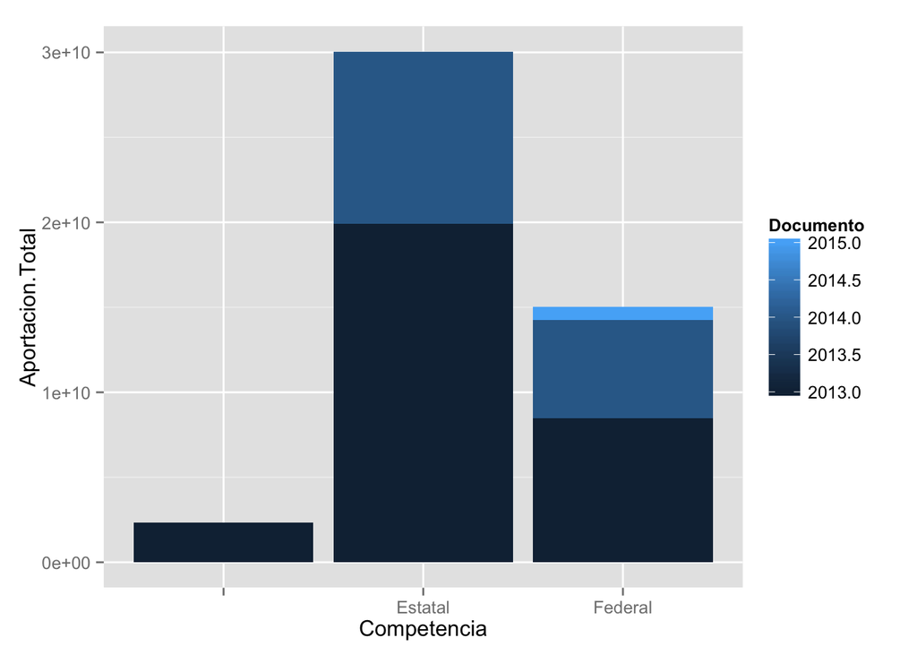

```r
ggplot(FIM, aes(x = Competencia, y= Aportacion.Total , fill = Documento))+
  geom_bar(stat="identity" )
```

[figure not shown]

```r
ggplot(FIM, aes(x = Competencia, y= Aportacion.Total)) +
  geom_bar(stat="identity" )+
  facet_grid(Estado ~ Documento)
```

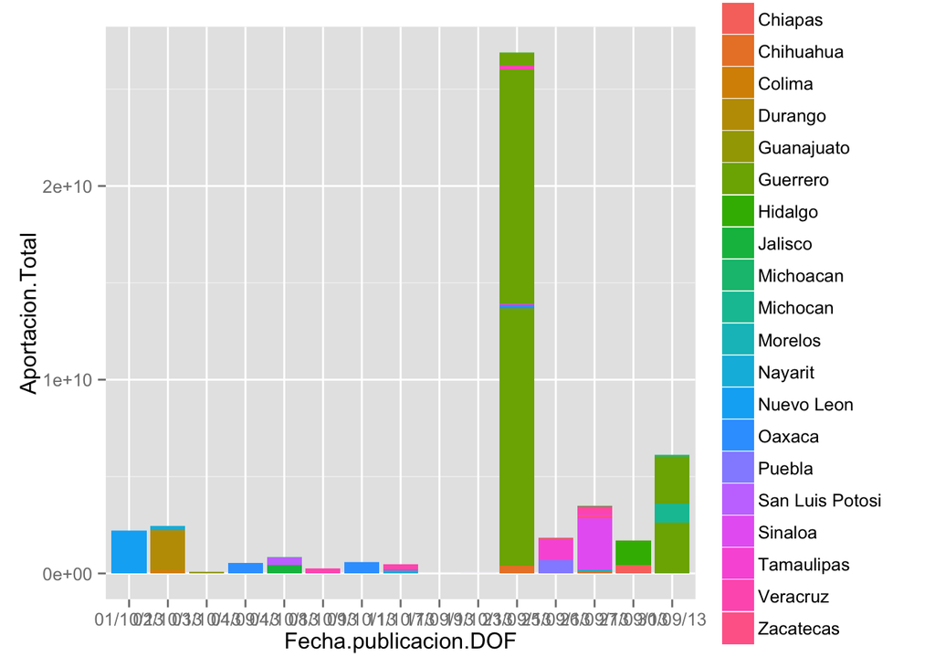

```r
ggplot(FIM, aes(x = Fecha.publicacion.DOF, y= Aportacion.Total, fill = Estado)) +geom_bar(stat="identity" )
```

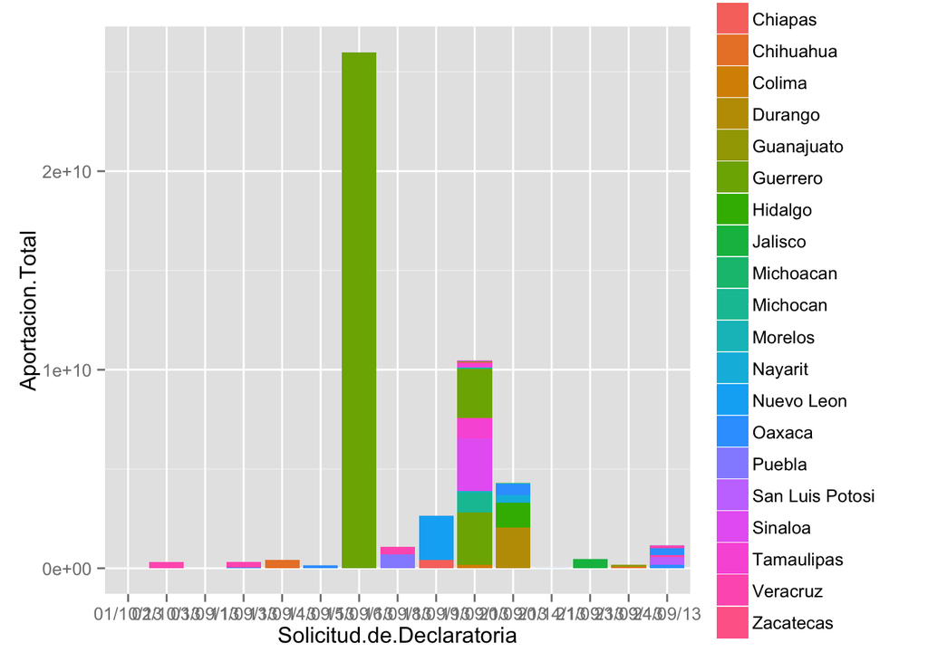

```r
ggplot(FIM, aes(x = Solicitud.de.Declaratoria, y= Aportacion.Total, fill = Estado)) +geom_bar(stat="identity" )
```

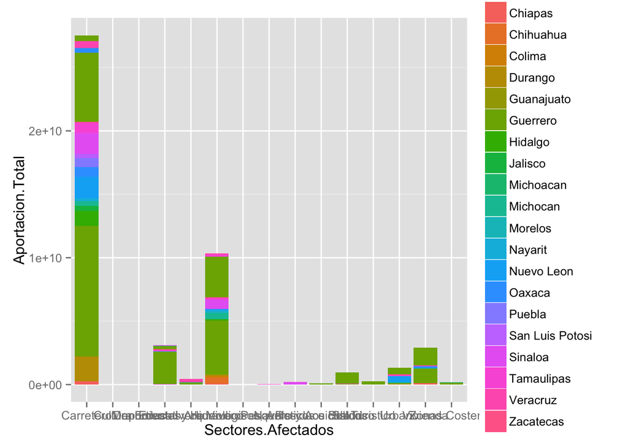

```r
ggplot(FIM, aes(x = Sectores.Afectados, y= Aportacion.Total, fill = Estado)) +geom_bar(stat="identity" )
```

```r
write.csv(FIM, file = "FIM.csv", row.names=FALSE)
```